# Likelihood Function

Generating some data with a know probability of germination -> myP

```r
myP<-0.67
myData<-rbinom(n=10,size=1,prob=myP)
myData
```

```
 [1] 1 1 1 1 0 1 1 0 1 0
```

```r
mean(myData)
```

```
[1] 0.7
```

Binomial Likelihood Function

```r
nllBinomial<-function(parmEstimate,seedlingDat){

  nllik<- -sum(dbinom(seedlingDat,size=1,parmEstimate,log=TRUE))

  cat("nllik= ",nllik,sep=" ",fill=T)
  return(nllik)
}

nllBinomial(0.6,myData)
```

```
nllik=  6.324652
[1] 6.324652
```

```r
nllBinomial(0.1,myData)
```

```
nllik=  16.43418
[1] 16.43418
```

Minimizing the function using optim

```r
parVec<-c(0.1) # Initial parameter values
outLogReg<-optim(par=parVec,fn=nllBinomial,method="L-BFGS-B",lower=c(0.01),upper=c(0.99),seedlingDat=myData)
```

```
nllik=  16.43418
nllik=  16.36786
nllik=  16.5012
nllik=  13.88586
nllik=  13.88586
nllik=  13.60701
nllik=  10.07198
nllik=  10.05039
nllik=  10.09367
nllik=  8.576073
nllik=  8.560991
nllik=  8.591218
nllik=  6.609054
nllik=  6.602835
nllik=  6.61531
nllik=  6.11829
nllik=  6.117376
nllik=  6.119248
nllik=  6.108907
nllik=  6.109091
nllik=  6.108772
nllik=  6.108643
nllik=  6.108661
nllik=  6.108673
nllik=  6.108643
nllik=  6.108667
nllik=  6.108667
nllik=  6.108643
nllik=  6.108667
nllik=  6.108667
```

```r
outLogReg$par #
```

```
[1] 0.6999994
```

Plotting the likelihood function

```r
library(purrr)
probabilityVector<-seq(from=0, to=1,length=100)
llikOut<-map_dbl(probabilityVector,nllLogBinomial,seedlingDat=myData)
```

[output not shown]

[output cut: 45 more lines]

```
nllik=  8.739062
nllik=  8.965317
nllik=  9.216123
nllik=  9.495597
nllik=  9.80904
nllik=  10.16344
nllik=  10.56828
nllik=  11.03683
nllik=  11.58856
nllik=  12.25368
nllik=  13.08276
nllik=  14.17066
nllik=  15.73034
nllik=  18.44139
nllik=  Inf
```

[figure not shown]

```r
plot(probabilityVector,-llikOut,typ='l')
```

Problem: Fit a linear regression to height vs weight data via maximum likelihood weight~Normal(mu,sigma) mu<-intercept + B*height

```r
library(rethinking)
data("Howell1")
myData<-Howell1
myData<-myData[myData$age>18,]
head(myData)
```

|  | height | weight | age | male |
| --- | --- | --- | --- | --- |
| 1 | 151.765 | 47.82561 | 63 | 1 |
| 2 | 139.700 | 36.48581 | 63 | 0 |
| 3 | 136.525 | 31.86484 | 65 | 0 |
| 4 | 156.845 | 53.04191 | 41 | 1 |
| 5 | 145.415 | 41.27687 | 51 | 0 |
| 6 | 163.830 | 62.99259 | 35 | 1 |

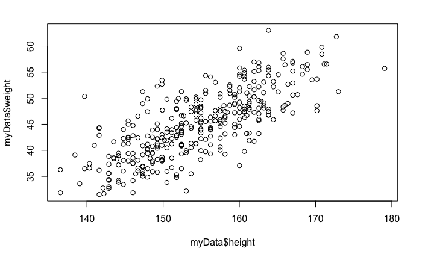

```r
plot(myData$height,myData$weight)
```

This likelihood function assumes a sd->1

```r
nllRegression<-function(parmVector,weightDat,heightDat){

  intercept<-parmVector[1]
  B<-parmVector[2]

  w<-weightDat
  h<-heightDat
  mu<-intercept + B*h

  nllik<- -sum(dnorm(x=w,mean=mu,sd=1,log=TRUE))

  cat("nllik= ",nllik,sep=" ",fill=T)
  return(nllik)}

nllRegression(c(1,1),weightDat=myData$weight,heightDat=myData$height)
```

```
nllik=  2121050
[1] 2121050
```

Fitting the linear regression using maximum likelihood

```r
parVec<-c(0.1,0.1) # Initial parameter values
outReg<-optim(par=parVec,fn=nllRegression,method="L-BFGS-B",lower=c(-Inf,-Inf),upper=c(Inf,Inf), weightDat=myData$weight,heightDat=myData$height)
```

[output not shown]

[output cut: 40 more lines]

```
nllik=  3432.287
nllik=  3432.287
nllik=  3432.287
nllik=  3436.435
nllik=  3436.435
nllik=  3432.287
nllik=  3432.287
nllik=  3432.287
nllik=  3436.435
nllik=  3436.435
nllik=  3432.287
nllik=  3432.287
nllik=  3432.287
nllik=  3436.435
nllik=  3436.435
```

```r
outReg$par #
```

```
[1] -51.6295921   0.6251449
```

Plotting the fit

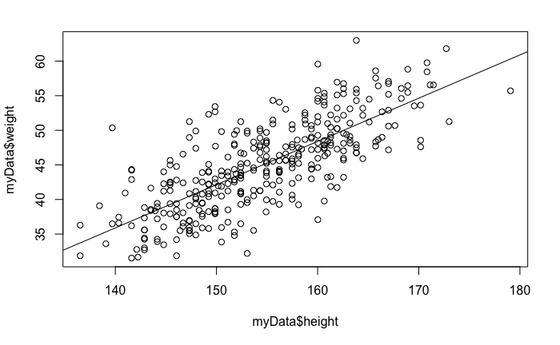

```r
plot(myData$height,myData$weight)
abline(a=outReg$par[1],b=outReg$par[2])
```

PROBLEM 1: Modify the likelihood function to fit the sd to the data and replot the fit.

Solution:

```r
library(rethinking)
data("Howell1")
myData<-Howell1
myData<-myData[myData$age>18,]
head(myData)
```

|  | height | weight | age | male |
| --- | --- | --- | --- | --- |
| 1 | 151.765 | 47.82561 | 63 | 1 |
| 2 | 139.700 | 36.48581 | 63 | 0 |
| 3 | 136.525 | 31.86484 | 65 | 0 |
| 4 | 156.845 | 53.04191 | 41 | 1 |
| 5 | 145.415 | 41.27687 | 51 | 0 |
| 6 | 163.830 | 62.99259 | 35 | 1 |

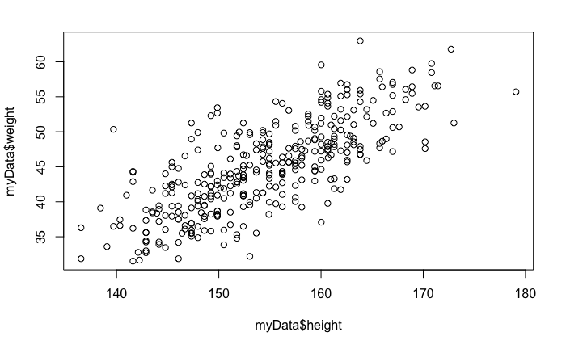

```r
plot(myData$height,myData$weight)
```

Modify the likelihood to also fit sd

```r
nllRegression<-function(parmVector,weightDat,heightDat,print=F){

  intercept<-parmVector[1]
  B<-parmVector[2]
  mySD<-parmVector[3]

  w<-weightDat
  h<-heightDat
  mu<-intercept + B*h

  nllik<- -sum(dnorm(x=w,mean=mu,sd=mySD,log=TRUE))

  if (print) cat("nllik= ",nllik,sep=" ",fill=T)
  return(nllik)}
```

Testing the likelihood function:

```r
nllRegression(c(1,1,10),weightDat=myData$weight,heightDat=myData$height)
```

[output not shown]

Next, minimizing the negative log likelihood. By default optim performs minimization–that is why we use the NEGATIVE log likelihood

```r
parVec<-c(0.1,0.1,10) # Initial parameter values
outReg<-optim(par=parVec,fn=nllRegression,method="L-BFGS-B",lower=c(-Inf,-Inf, 0.01),upper=c(Inf,Inf, Inf), weightDat=myData$weight,heightDat=myData$height,print=F)
outReg$par #
```

```
[1] -51.6295921   0.6251449   4.2428686
```

```r
outReg
```

```
$par
[1] -51.6295921   0.6251449   4.2428686

$value
[1] 991.0056

$counts
function gradient
      42       42

$convergence
[1] 0

$message
[1] "CONVERGENCE: REL_REDUCTION_OF_F <= FACTR*EPSMCH"
```

Plotting the fit

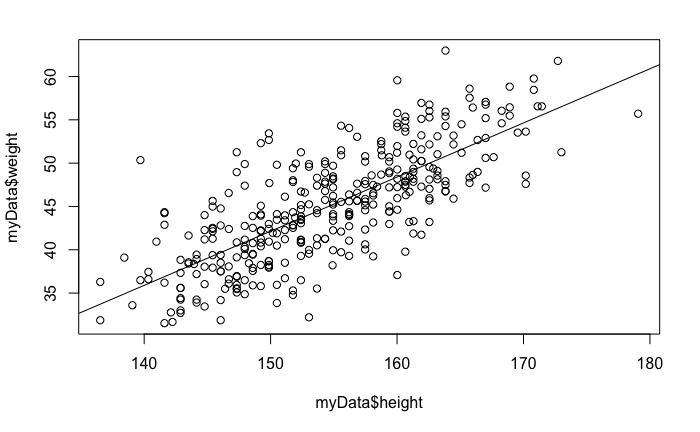

```r
plot(myData$height,myData$weight)
abline(a=outReg$par[1],b=outReg$par[2])
```

PROBLEM 2: Fit the linear regression using the R lm function. Compare the parameter estimates.

Examining the data

```r
head(myData)
```

|  | height | weight | age | male |
| --- | --- | --- | --- | --- |
| 1 | 151.765 | 47.82561 | 63 | 1 |
| 2 | 139.700 | 36.48581 | 63 | 0 |
| 3 | 136.525 | 31.86484 | 65 | 0 |
| 4 | 156.845 | 53.04191 | 41 | 1 |
| 5 | 145.415 | 41.27687 | 51 | 0 |
| 6 | 163.830 | 62.99259 | 35 | 1 |

```r
lmFit<-lm(weight~height,data=myData)
summary(lmFit)
```

```
Call:
lm(formula = weight ~ height, data = myData)

Residuals:
     Min       1Q   Median       3Q      Max
-11.8344  -3.0747  -0.2775   2.8402  14.6456

Coefficients:
             Estimate Std. Error t value Pr(>|t|)
(Intercept) -51.62959    4.56320  -11.31   <2e-16 ***
height        0.62514    0.02947   21.21   <2e-16 ***
---
Signif. codes:  0 ‘***’ 0.001 ‘**’ 0.01 ‘*’ 0.05 ‘.’ 0.1 ‘ ’ 1

Residual standard error: 4.255 on 344 degrees of freedom
Multiple R-squared:  0.5667,    Adjusted R-squared:  0.5655
F-statistic:   450 on 1 and 344 DF,  p-value: < 2.2e-16
```

Question: How to the lm fits compare to the maximum likelhood fits? Note that lm uses ordinary least squares regression and not likelihood.

PROBLEM 3: Fit the linear regression using the Rethinking QUAP function. Compare the parameter estimates.

```r
library(rethinking)
lm.qa <- quap(
    alist(
        weight ~ dnorm(mu,sd) ,  # normal likelihood
        sd ~ dexp(1),     # exponential prior
        mu<-intercept + beta*height,
        intercept~dnorm(0,10),
        beta~dnorm(0,10)
    ) ,
    data=list(weight=myData$weight,height=myData$height) )
```

```r
precis(lm.qa)
```

|  | mean | sd | 5.5% | 94.5% |
| --- | --- | --- | --- | --- |
| sd | 4.24 | 0.16 | 3.98 | 4.50 |
| intercept | -42.77 | 4.18 | -49.45 | -36.09 |
| beta | 0.57 | 0.03 | 0.52 | 0.61 |

Note the differences between the QUAP fit and the fits above. What do you think is causing this? Let’s look at a plot.

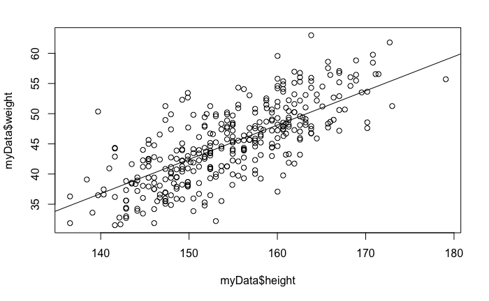

```r
plot(myData$height,myData$weight)
abline(a=summary(lm.qa)$mean[2],b=summary(lm.qa)$mean[3])
```

Part of the problem is that the intercept and and beta are highly correlated so that different combinations of each fit the data well.

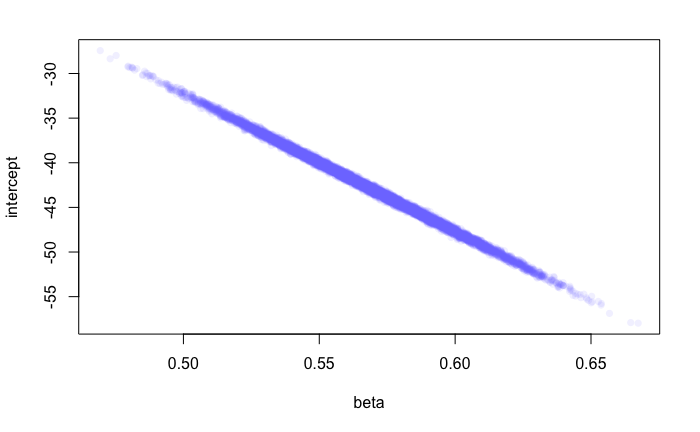

```r
post <- extract.samples(lm.qa)
plot( intercept ~ beta , post , col=col.alpha(rangi2,0.1) , pch=16 )
```

```r
weight<-myData$weight
```

[output not shown]